# MISO DA-RT Market Monitoring Report

# Monitoring Summary

**Market Date:** September 1, 2026

ALERT: 4 hub-hour DA-RT divergence alerts detected.

The monitoring rule flags a hub-hour when the absolute Real-Time minus Day-Ahead LMP spread exceeds that hub’s historical 99th percentile.

The historical baseline uses **July 1-August 31, 2026**, excluding the monitored day.

# Primary Alerts

| Hour Ending | Hub | DA LMP (USD/MWh) | RT LMP (USD/MWh) | RT - DA (USD/MWh) | Historical P99 (USD/MWh) |
| --- | --- | --- | --- | --- | --- |
| 19 | MICHIGAN.HUB | 569.47 | 1242.13 | 672.66 | 294.19 |
| 19 | ILLINOIS.HUB | 513.90 | 1163.71 | 649.81 | 270.89 |
| 19 | INDIANA.HUB | 562.84 | 1153.88 | 591.04 | 285.88 |
| 19 | MINN.HUB | 591.73 | 1033.35 | 441.62 | 334.56 |

# DA-RT Spread by Hub and Hour

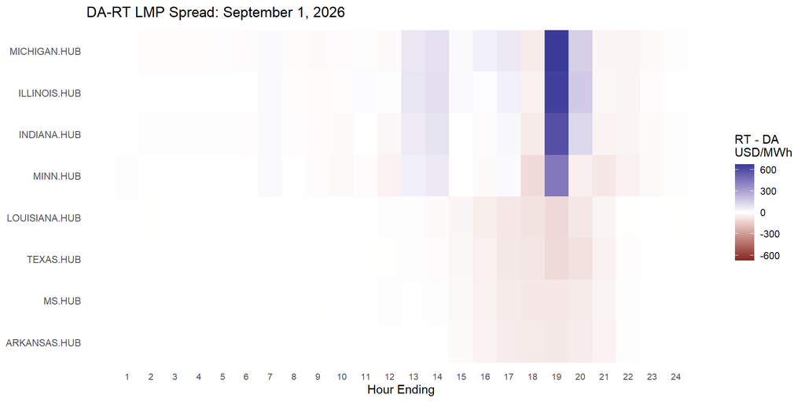

# Largest Absolute Spreads

| Hour Ending | Hub | DA LMP | RT LMP | RT - DA | Historical P99 | Alert |
| --- | --- | --- | --- | --- | --- | --- |
| 19 | MICHIGAN.HUB | 569.47 | 1242.13 | 672.66 | 294.19 | YES |
| 19 | ILLINOIS.HUB | 513.90 | 1163.71 | 649.81 | 270.89 | YES |
| 19 | INDIANA.HUB | 562.84 | 1153.88 | 591.04 | 285.88 | YES |
| 19 | MINN.HUB | 591.73 | 1033.35 | 441.62 | 334.56 | YES |
| 20 | ILLINOIS.HUB | 329.02 | 496.30 | 167.28 | 270.89 |  |
| 20 | MICHIGAN.HUB | 389.59 | 539.77 | 150.18 | 294.19 |  |
| 20 | INDIANA.HUB | 376.63 | 496.75 | 120.12 | 285.88 |  |
| 19 | LOUISIANA.HUB | 264.24 | 150.66 | -113.58 | 117.49 |  |
| 19 | TEXAS.HUB | 244.65 | 134.94 | -109.71 | 121.93 |  |
| 18 | MINN.HUB | 461.08 | 358.43 | -102.65 | 334.56 |  |

# Historical Context

| Hub | Historical P99 \|RT - DA\| (USD/MWh) |
| --- | --- |
| MINN.HUB | 334.56 |
| MICHIGAN.HUB | 294.19 |
| INDIANA.HUB | 285.88 |
| ILLINOIS.HUB | 270.89 |
| TEXAS.HUB | 121.93 |
| LOUISIANA.HUB | 117.49 |
| MS.HUB | 113.18 |
| ARKANSAS.HUB | 101.20 |

# Robust Diagnostic

In addition to the primary empirical-percentile alert, the workflow calculates a robust deviation measure using the historical median and median absolute deviation (MAD) for each hub and hour.

This diagnostic is retained for context but is **not used as the primary alert trigger**.

| Hour Ending | Hub | RT - DA | Historical Median | Robust Z | Primary Alert |
| --- | --- | --- | --- | --- | --- |
| 19 | ILLINOIS.HUB | 649.81 | -31.17 | 18.57 | YES |
| 19 | MICHIGAN.HUB | 672.66 | -31.18 | 15.91 | YES |
| 19 | INDIANA.HUB | 591.04 | -28.09 | 13.51 | YES |
| 14 | ILLINOIS.HUB | 101.14 | -5.37 | 12.05 |  |
| 19 | MINN.HUB | 441.62 | -35.59 | 9.98 | YES |
| 13 | ILLINOIS.HUB | 76.55 | -3.00 | 9.92 |  |
| 14 | MICHIGAN.HUB | 93.90 | -3.42 | 6.99 |  |
| 13 | MICHIGAN.HUB | 71.49 | -2.90 | 6.67 |  |
| 13 | MINN.HUB | 49.75 | -3.50 | 6.18 |  |
| 14 | INDIANA.HUB | 84.76 | -7.41 | 6.07 |  |

# Interpretation

The automated historical-baseline rule identified 4 unusually large DA-RT hub-hour divergences. The alerts were concentrated at HE19. The largest deviation occurred at MICHIGAN.HUB, where Real-Time LMP exceeded Day-Ahead LMP by approximately 673 USD/MWh.

# Methodology

The workflow:

1. Downloads and caches historical MISO Day-Ahead ExPost and Real-Time Final LMP reports.
2. Builds a 62-day historical baseline for eight named hubs.
3. Calculates hub-specific empirical 99th-percentile absolute DA-RT spread thresholds.
4. Evaluates the selected market day against those thresholds.
5. Generates automated alert tables, visualizations, and diagnostic statistics.

The alert identifies unusually large price divergence relative to recent historical behavior. It does not, by itself, establish the cause of the divergence.